# Autoregressive Integrated Moving Average (ARIMA)

ARIMA, short for AutoRegressive Integrated Moving Average, is a powerful statistical model used to forecast time series data by capturing autocorrelations and trends.

ARIMA combines three key ideas:

- AR (AutoRegressive): regression of the variable on its own lagged (past) values
- I (Integrated): differencing of raw observations to make the time series stationary
- MA (Moving Average): modeling of the error term as a linear combination of past error terms

An ARIMA(p, d, q) model consists of:

- p: number of autoregressive (AR) terms
- d: number of nonseasonal differences needed for stationarity
- q: number of moving average (MA) terms

# Seasonal ARIMA (SARIMA)

When ARIMA has a seasonal component, it is referred to as SARIMA. In addition to non-seasonal components of order p, d and q, this model also contains seasonal components of order P, D and Q.

(Non-Seasonal) ARIMA + seasonal terms = Seasonal ARIMA

SARIMA(p,d,q)(P,D,Q)m  
(p,d,q) is non-seasonal component  
(P,D,Q) is seasonal component  
m is number of periods per season

where  
- d = Number of lag differences  
- p = Number of ordinary Autoregressive Lags  
- q = Number of ordinary Moving average lags  
- D = Number of seasonal differences  
- P = Number of seasonal Autoregressive Lags  
- Q = Number of seasonal Moving Average lags  
- m = Seasonal period or number of observations per year

```python
import numpy as np
import pandas as pd
import matplotlib.pyplot as plt

from statsmodels.tsa.stattools import adfuller, kpss
from statsmodels.graphics.tsaplots import plot_pacf, plot_acf
from statsmodels.tsa.stattools import acf, pacf

import statsmodels.api as sm
from statsmodels.tsa.arima.model import ARIMA
from statsmodels.tsa.statespace.sarimax import SARIMAX
from statsmodels.tsa.arima_process import ArmaProcess
from statsmodels.stats.diagnostic import acorr_ljungbox

import warnings
warnings.filterwarnings("ignore")
```

## Steps in Model Selection

1. Check Stationarity
2. Apply transformations, if needed
3. Examine ACF, PACF
4. Grid Search for ARIMA
5. Fit ARIMA with lowest AIC
6. Examine Residuals
7. Forecast

### Air Passengers Data

This dataset contains monthly air passenger counts for Ireland from 2010 to 2018. Our focus is on “international”, which is the number of international passengers in thousands.

```python
passengers = pd.read_csv('air_passengers.csv',
                 parse_dates = ['date'], date_format='%Y-%m-%d',
                 index_col='date')
passengers = passengers.loc[passengers.name =='Ireland',:]
passengers.columns = [col.lower() for col in passengers.columns]
passengers.head()
passengers = passengers.asfreq('MS')  # Specifies monthly frequency
```

#### Split Data

```python
h = 12
train = passengers.iloc[:-h]
test = passengers.iloc[-h:]
train.head()
```

| date | name | total | domestic | international | total_os |
| --- | --- | --- | --- | --- | --- |
| 2010-01-01 | Ireland | 1488.034 | 30.502 | 1457.532 | 1522.530 |
| 2010-02-01 | Ireland | 1548.150 | 38.198 | 1509.952 | 1579.746 |
| 2010-03-01 | Ireland | 1865.279 | 44.373 | 1820.906 | 1898.331 |
| 2010-04-01 | Ireland | 1464.440 | 25.856 | 1438.584 | 1468.642 |
| 2010-05-01 | Ireland | 1968.408 | 29.101 | 1939.307 | 1963.063 |

### 1. Check for Stationarity

As discussed previously, a pre-requisite for the use of ARIMA is that the series be stationary. Stationarity can be tested  
- Visual Examination of time series plot  
- Statistical tests (e.g., Augmented Dickey Fuller)

```
ADF Test Statistic: 2.10841617491774
p-value: 0.9987982794721632
----------------------------------------------------------------------------------------------------
```

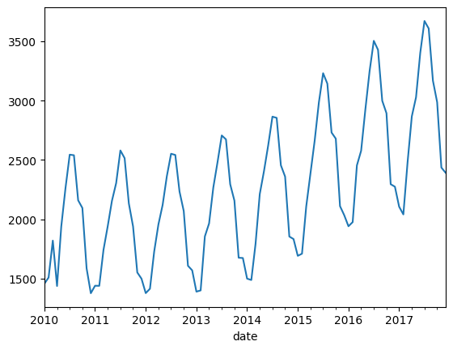

```python
print('ADF Test Statistic:', adfuller(train.international)[0])
print('p-value:', adfuller(train.international)[1])
print('-'*100)
train.international.plot()
plt.show()
```

### 2. Apply Tranformations

A non-stationary series can be made weakly stationary by

- Stabilizing Variance
- Seasonal Differencing
- Lag Differencing

```
Value of lambda to stabilize variance  0.1251694035881738
----------------------------------------------------------------------------------------------------
ADF Test Statistic: 2.497017976280054
p-value: 0.9990488826509608
----------------------------------------------------------------------------------------------------
```

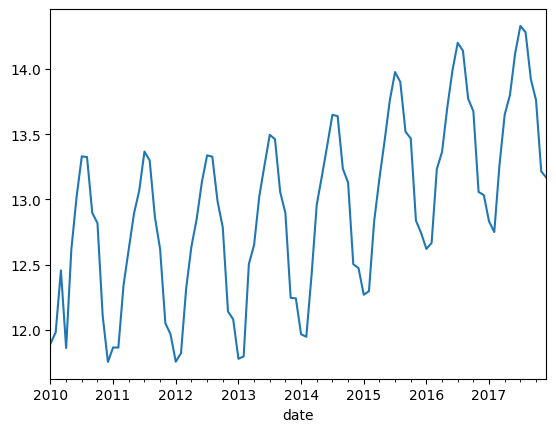

```python
from scipy.stats import boxcox
boxcox_lambda = boxcox(train.international)[1]
print('Value of lambda to stabilize variance ', boxcox_lambda)
print('-'*100)
international_boxcox = boxcox(train.international)[0]
transformed = pd.DataFrame({'international': train.international,
                            'international_boxcox': international_boxcox},index = train.index)

print('ADF Test Statistic:', adfuller(transformed.international_boxcox)[0])
print('p-value:', adfuller(transformed.international_boxcox)[1])
print('-'*100)
transformed.international_boxcox.plot()
plt.show()
```

```
ADF Test Statistic: -1.9298091565702977
p-value: 0.318170463781791
----------------------------------------------------------------------------------------------------
```

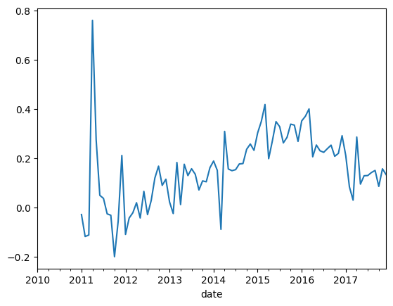

```python
transformed['international_boxcox_sdiff'] = transformed.international_boxcox.diff(12)
print('ADF Test Statistic:', adfuller(transformed.international_boxcox_sdiff.dropna())[0])
print('p-value:', adfuller(transformed.international_boxcox_sdiff.dropna())[1])
print('-'*100)
transformed.international_boxcox_sdiff.plot()
plt.show()
```

```
ADF Test Statistic: -11.438962764313137
p-value: 6.246469499030272e-21
----------------------------------------------------------------------------------------------------
```

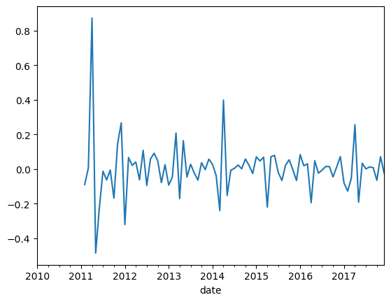

```python
transformed['international_boxcox_sdiff_diff'] = transformed.international_boxcox_sdiff.diff()
print('ADF Test Statistic:', adfuller(transformed.international_boxcox_sdiff_diff.dropna())[0])
print('p-value:', adfuller(transformed.international_boxcox_sdiff_diff.dropna())[1])
print('-'*100)
transformed.international_boxcox_sdiff_diff.plot()
plt.show()
```

Series was transformed by

- boxcox transformation
- 1 seasonal difference
- 1 lag difference

### 3. Examine ACF and PACF

ACF and PACF plots are useful for identifying whether the data follows an AR, MA or ARMA process. In the case of AR and MA, it can help identify the order. For an ARMA process, these plots can offer hints or guidance on values of p, q, P and Q that may be good.

#### Examine PACF

```python
pacf(transformed.international_boxcox_sdiff_diff.dropna(), nlags = 24)
```

```
array([ 1.        , -0.38179545, -0.36576069, -0.2428943 , -0.13600033,
       -0.07762104, -0.23882328, -0.22004673,  0.00203172, -0.06315497,
       -0.05722584,  0.08102891, -0.13910396, -0.02415981,  0.03571549,
        0.00952263, -0.12882297, -0.06916871,  0.02862738,  0.00631009,
        0.20110304, -0.05526832, -0.11413771,  0.1375231 , -0.17580455])
```

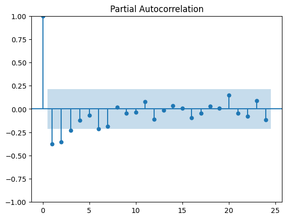

```python
plot_pacf(transformed.international_boxcox_sdiff_diff.dropna(), lags=24)
plt.show()
```

#### Examine ACF

```python
acf(transformed.international_boxcox_sdiff_diff.dropna(),nlags=24)
```

```
array([ 1.        , -0.3771955 , -0.16266051,  0.04513516,  0.04905185,
       -0.00578219, -0.13452645,  0.04738344,  0.15790336, -0.10926659,
       -0.02696399,  0.10150151, -0.12930038,  0.06681487,  0.01061072,
       -0.01262272, -0.05860402,  0.03182974,  0.08314871, -0.04756108,
        0.03160406, -0.09461414,  0.02563588,  0.08899322, -0.16338644])
```

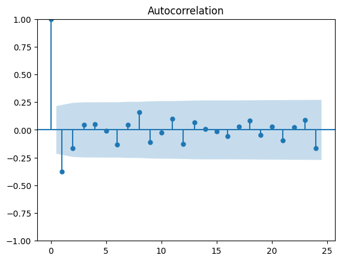

```python
plot_acf(transformed.international_boxcox_sdiff_diff.dropna(),lags=24)
plt.show()
```

Neither the PACF nor the ACF show a clear cut-off. Thus, both AR and MA processes are at work. Based on the PACF plot, it appears like p may be in the neighborhood of 3 and P is either 0, 1 or 2. Based on the ACF plot, it appears like q may be in the neighborhood of 2, while Q may be 0, 1 or 2.

### 4. Grid Search

An exhaustive search of all combinations of p, q, P and Q is likely to be extremely resource intensive. Therefore, we will use the PACF and ACF plot results to guide the choice of order values to test.

ARIMA has a mechanism to conduct differencing but not variance stabilization, so the latter must be done before the series is fed to ARIMA.

```python
h = 12
train_lambda = boxcox(train.international)[1]
train.loc[:,['bc_international']] = boxcox(train.international)[0]
test.loc[:,['bc_international']] = boxcox(test.international, lmbda = train_lambda)
```

```python
from itertools import product

# Stationarity Values and seasonality
d, D, s = 1, 1, 12

p_values = [0, 1, 2, 3, 4, 5, 6]
q_values = [0, 1, 2, 3, 4]
P_values = [0, 1, 2]
Q_values = [0, 1, 2]

results = []

for p, q, P, Q in product(p_values, q_values, P_values, Q_values):
    order = (p, d, q)
    seasonal_order = (P, D, Q, s)
    rec = {
        "order": order,
        "seasonal_order": seasonal_order,
        "aic": np.nan,
        "bic": np.nan,
        "converged": False
    }
    try:
        model = SARIMAX(
            train.bc_international,
            order=order,
            seasonal_order=seasonal_order,
            enforce_stationarity=True,
            enforce_invertibility=True,
            trend=None
        )
        fit = model.fit(disp=False, maxiter=200)
        rec["aic"] = fit.aic
        rec["bic"] = fit.bic
        rec["converged"] = fit.mle_retvals.get("converged", False)
    except Exception as e:
        rec["error"] = str(e)

    results.append(rec)

results_df = pd.DataFrame(results).sort_values("aic", na_position="last").reset_index(drop=True)
```

```python
results_df.head(20)
```

|  | order | seasonal_order | aic | bic | converged |
| --- | --- | --- | --- | --- | --- |
| 0 | (0, 1, 2) | (2, 1, 2, 12) | -107.593119 | -90.661235 | True |
| 1 | (6, 1, 2) | (2, 1, 1, 12) | -107.223295 | -78.197207 | True |
| 2 | (6, 1, 2) | (2, 1, 2, 12) | -106.908271 | -75.463343 | True |
| 3 | (1, 1, 1) | (2, 1, 2, 12) | -106.712288 | -89.780403 | True |
| 4 | (5, 1, 3) | (2, 1, 2, 12) | -106.685574 | -75.240646 | True |
| 5 | (5, 1, 3) | (2, 1, 1, 12) | -106.168788 | -77.142701 | True |
| 6 | (2, 1, 1) | (2, 1, 2, 12) | -106.013604 | -86.662879 | True |
| 7 | (0, 1, 2) | (2, 1, 1, 12) | -105.965175 | -91.452132 | True |
| 8 | (2, 1, 2) | (2, 1, 2, 12) | -105.918854 | -84.149288 | True |
| 9 | (1, 1, 2) | (2, 1, 2, 12) | -105.583451 | -86.232726 | True |
| 10 | (6, 1, 3) | (2, 1, 1, 12) | -105.278130 | -73.833202 | True |
| 11 | (1, 1, 1) | (2, 1, 1, 12) | -104.997965 | -90.484921 | True |
| 12 | (6, 1, 2) | (2, 1, 0, 12) | -104.982266 | -78.375020 | True |
| 13 | (6, 1, 3) | (2, 1, 2, 12) | -104.910942 | -71.047174 | True |
| 14 | (0, 1, 1) | (2, 1, 2, 12) | -104.736535 | -90.223492 | True |
| 15 | (2, 1, 1) | (2, 1, 1, 12) | -104.619768 | -87.687884 | True |
| 16 | (0, 1, 4) | (2, 1, 2, 12) | -104.517545 | -82.747979 | True |
| 17 | (5, 1, 2) | (2, 1, 2, 12) | -104.330200 | -75.304112 | False |
| 18 | (3, 1, 1) | (2, 1, 2, 12) | -104.312516 | -82.542950 | True |
| 19 | (2, 1, 3) | (2, 1, 1, 12) | -104.188951 | -82.419386 | True |

### 5a. Fit ARIMA with lowest AIC

```python
sarima_model  = SARIMAX(train.bc_international,
                        order = (0,1,2),
                        seasonal_order=(2,1,2,12))
result = sarima_model.fit()
result.summary()
```

SARIMAX Results

| Dep. Variable: | bc_international | No. Observations: | 96 |
| --- | --- | --- | --- |
| Model: | SARIMAX(0, 1, 2)x(2, 1, 2, 12) | Log Likelihood | 60.796 |
| Date: | Mon, 13 Apr 2026 | AIC | -107.591 |
| Time: | 17:40:49 | BIC | -90.659 |
| Sample: | 01-01-2010 | HQIC | -100.789 |
|  | - 12-01-2017 |  |  |
| Covariance Type: | opg |  |  |

|  | coef | std err | z | P>\|z\| | [0.025 | 0.975] |
| --- | --- | --- | --- | --- | --- | --- |
| ma.L1 | -0.5143 | 0.155 | -3.312 | 0.001 | -0.819 | -0.210 |
| ma.L2 | -0.2437 | 0.128 | -1.909 | 0.056 | -0.494 | 0.007 |
| ar.S.L12 | -1.1730 | 0.259 | -4.530 | 0.000 | -1.681 | -0.665 |
| ar.S.L24 | -0.9551 | 0.271 | -3.527 | 0.000 | -1.486 | -0.424 |
| ma.S.L12 | 1.1570 | 0.629 | 1.839 | 0.066 | -0.076 | 2.390 |
| ma.S.L24 | 0.7855 | 0.817 | 0.961 | 0.336 | -0.816 | 2.387 |
| sigma2 | 0.0110 | 0.006 | 1.944 | 0.052 | -8.87e-05 | 0.022 |

| Ljung-Box (L1) (Q): | 0.00 | Jarque-Bera (JB): | 1143.33 |
| --- | --- | --- | --- |
| Prob(Q): | 0.98 | Prob(JB): | 0.00 |
| Heteroskedasticity (H): | 0.10 | Skew: | 2.92 |
| Prob(H) (two-sided): | 0.00 | Kurtosis: | 20.22 |

Warnings:  
[1] Covariance matrix calculated using the outer product of gradients (complex-step).

### 6a. Examine Residuals

```python
print(acorr_ljungbox(result.resid, lags = 12).iloc[11,:])
```

```
lb_stat      18.508378
lb_pvalue     0.101104
Name: 12, dtype: float64
```

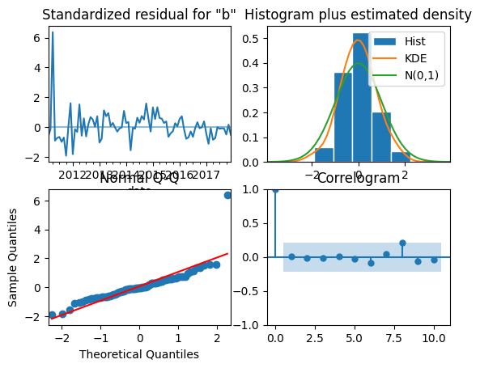

```python
result.plot_diagnostics()
plt.show()
```

### 7a. Forecast

```python
from scipy.special import inv_boxcox
forecasts = test.copy()
forecasts['sarima1'] = inv_boxcox(result.get_prediction(start = test.index[0], end = test.index[-1]).predicted_mean, train_lambda)
```

#### Accuracy

```python
from sklearn.metrics import root_mean_squared_error
root_mean_squared_error(test.international, forecasts['sarima1'])
```

```
85.53065221238754
```

### 5b Fit ARIMA based on lowest bic

```python
results_df.sort_values('bic').head()
```

|  | order | seasonal_order | aic | bic | converged |
| --- | --- | --- | --- | --- | --- |
| 37 | (0, 1, 1) | (0, 1, 0, 12) | -102.807755 | -97.970074 | True |
| 46 | (0, 1, 1) | (0, 1, 1, 12) | -102.476306 | -95.219784 | True |
| 56 | (0, 1, 2) | (0, 1, 0, 12) | -101.990378 | -94.733856 | True |
| 62 | (0, 1, 1) | (1, 1, 0, 12) | -101.902781 | -94.646259 | True |
| 72 | (1, 1, 1) | (0, 1, 0, 12) | -101.701050 | -94.444528 | True |

```python
sarima_model  = SARIMAX(train.bc_international,
                        order = (0,1,1),
                        seasonal_order=(0,1,0,12))
result = sarima_model.fit()
result.summary()
```

SARIMAX Results

| Dep. Variable: | bc_international | No. Observations: | 96 |
| --- | --- | --- | --- |
| Model: | SARIMAX(0, 1, 1)x(0, 1, [], 12) | Log Likelihood | 53.404 |
| Date: | Mon, 13 Apr 2026 | AIC | -102.808 |
| Time: | 17:40:50 | BIC | -97.970 |
| Sample: | 01-01-2010 | HQIC | -100.864 |
|  | - 12-01-2017 |  |  |
| Covariance Type: | opg |  |  |

|  | coef | std err | z | P>\|z\| | [0.025 | 0.975] |
| --- | --- | --- | --- | --- | --- | --- |
| ma.L1 | -0.7882 | 0.092 | -8.601 | 0.000 | -0.968 | -0.609 |
| sigma2 | 0.0160 | 0.001 | 12.811 | 0.000 | 0.014 | 0.018 |

| Ljung-Box (L1) (Q): | 0.81 | Jarque-Bera (JB): | 1084.51 |
| --- | --- | --- | --- |
| Prob(Q): | 0.37 | Prob(JB): | 0.00 |
| Heteroskedasticity (H): | 0.15 | Skew: | 2.80 |
| Prob(H) (two-sided): | 0.00 | Kurtosis: | 19.80 |

Warnings:  
[1] Covariance matrix calculated using the outer product of gradients (complex-step).

### 6b. Examine Residuals

```
lb_stat      18.608635
lb_pvalue     0.098421
Name: 12, dtype: float64
```

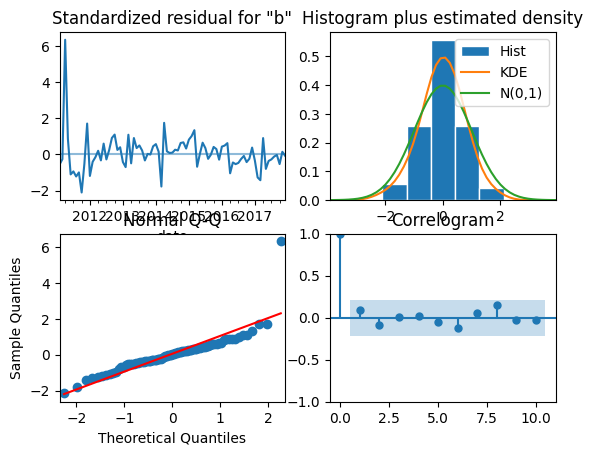

```python
print(acorr_ljungbox(result.resid, lags = 12).iloc[11,:])
result.plot_diagnostics()
plt.show()
```

### 7b. Forecast

```python
from scipy.special import inv_boxcox
forecasts['sarima2'] = inv_boxcox(result.get_prediction(start = test.index[0], end = test.index[-1]).predicted_mean, train_lambda)
```

#### Accuracy

```python
root_mean_squared_error(test.international, forecasts['sarima2'])
```

```
55.22119388243651
```

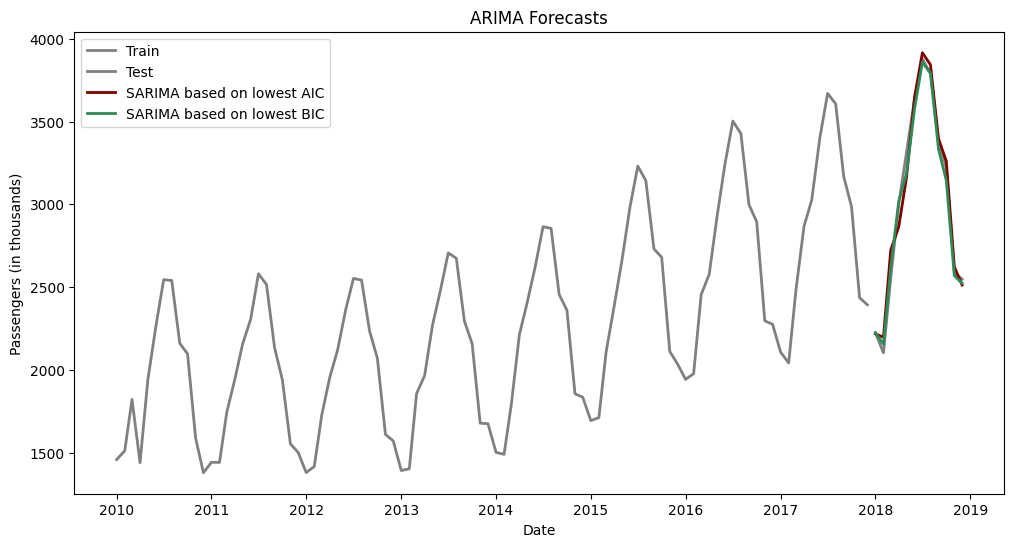

```python
plt.figure(figsize=(12,6))
plt.plot(train.index, train['international'], label='Train', color = 'gray', lw = 2)
plt.plot(test.index, test['international'], label='Test', color='gray', lw = 2)

plt.plot(test.index, forecasts['sarima1'], label='SARIMA based on lowest AIC', color = 'maroon', lw = 2)
plt.plot(test.index, forecasts['sarima2'], label='SARIMA based on lowest BIC', color = 'seagreen', lw = 2)

plt.title("ARIMA Forecasts")
plt.xlabel("Date")
plt.ylabel("Passengers (in thousands)")
plt.legend()
plt.show()
```

## ARIMA - nVidia Stock

```python
nvidia = pd.read_csv('nvda.csv',
                parse_dates=['Date'],
                date_format ='%Y-%m-%d')
nvidia = nvidia.loc[:,['Close_NVDA','Date']]
nvidia.rename(columns= {'Close_NVDA': 'price',
                                'Date': 'date'}, inplace=True)
nvidia.set_index('date',inplace=True)
nvidia = nvidia.resample('ME').last().asfreq('ME')
#nvidia = nvidia.asfreq('B').ffill()  # Specifies Business Days as frequency
nvidia.head()
```

| date | price |
| --- | --- |
| 2010-01-31 | 0.352792 |
| 2010-02-28 | 0.371359 |
| 2010-03-31 | 0.398868 |
| 2010-04-30 | 0.360127 |
| 2010-05-31 | 0.301214 |

#### Split Data

```python
h = 24
train = nvidia.iloc[:-h]
train.loc[:,['log_price']] = np.log(train.price)
test = nvidia.iloc[-h:]
```

### 1. Check Stationarity

```
ADF Test Statistic: -1.4020385838014435
p-value: 0.5812984065367767
----------------------------------------------------------------------------------------------------
```

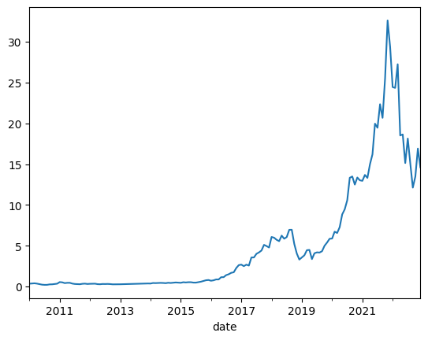

```python
print('ADF Test Statistic:', adfuller(train.price)[0])
print('p-value:', adfuller(train.price)[1])
print('-'*100)
train.price.plot()
plt.show()
```

### 2. Apply Tranformations

```
ADF Test Statistic: -0.06152279990631498
p-value: 0.9531386920555365
----------------------------------------------------------------------------------------------------
```

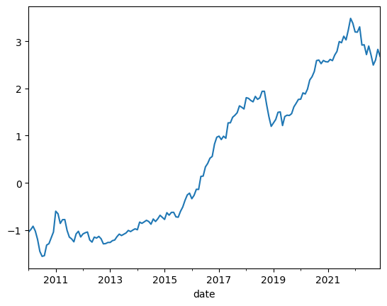

```python
price_log = np.log(train.price)
transformed = pd.DataFrame({'price': train.price,
                            'price_log': price_log},index = train.index)
print('ADF Test Statistic:', adfuller(transformed.price_log)[0])
print('p-value:', adfuller(transformed.price_log)[1])
print('-'*100)
transformed.price_log.plot()
plt.show()
```

```
ADF Test Statistic: -11.243991951849992
p-value: 1.778247109410505e-20
----------------------------------------------------------------------------------------------------
```

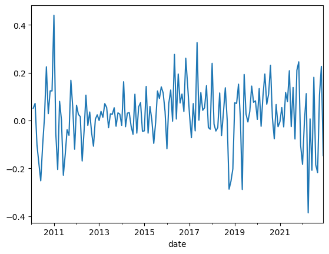

```python
transformed['price_log_diff'] = transformed.price_log.diff()
print('ADF Test Statistic:', adfuller(transformed.price_log_diff.dropna())[0])
print('p-value:', adfuller(transformed.price_log_diff.dropna())[1])
print('-'*100)
transformed.price_log_diff.plot()
plt.show()
```

### 3. Examine ACF and PACF

#### Examine PACF

```
[ 1.          0.08537434  0.0032863   0.03820218  0.12327129 -0.08220904
  0.0101646  -0.07897476  0.05217743  0.05178058 -0.01029353 -0.01962378
  0.00807969  0.09390853  0.08170639  0.0056917  -0.16029901 -0.02993799
  0.00868066 -0.05723807  0.05210538 -0.03793468 -0.05981817 -0.06585647
 -0.07947248]
--------------------------------------------------
```

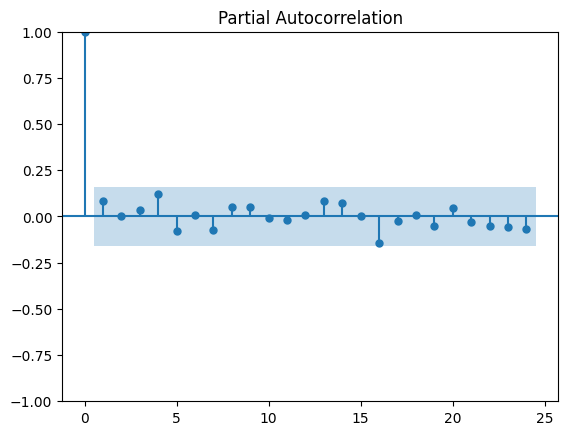

```python
print(pacf(transformed.price_log_diff.dropna(), nlags = 24))
print('-'*50)
plot_pacf(transformed.price_log_diff.dropna(), lags=24)
plt.show()
```

```
[ 1.00000000e+00  8.48235405e-02  1.04149817e-02  3.83449123e-02
  1.25453869e-01 -5.71916472e-02  2.37493969e-04 -6.49277704e-02
  4.64484748e-02  3.84596545e-02  1.30872897e-04 -3.33416885e-02
  2.75137252e-02  8.84819254e-02  8.28589555e-02  8.74522329e-03
 -1.22386212e-01 -1.72124111e-02  1.25608797e-02 -7.28204310e-02
 -1.50777821e-02 -1.22891495e-02 -3.82970551e-02 -5.39241089e-02
 -7.56323041e-02]
--------------------------------------------------
```

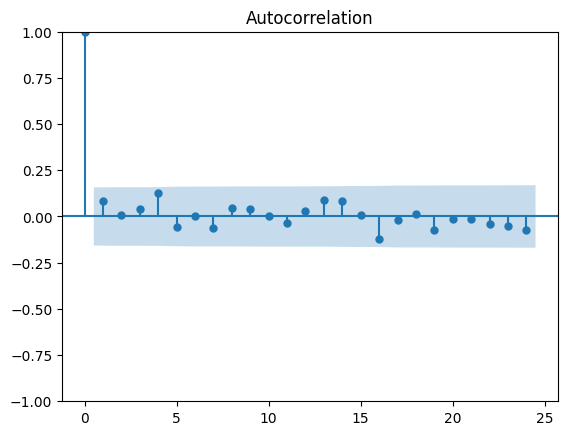

```python
print(acf(transformed.price_log_diff.dropna(),nlags=24))
print('-'*50)
plot_acf(transformed.price_log_diff.dropna(),lags=24)
plt.show()
```

### 4. Grid Search for ARIMA

```python
# Stationarity Values and seasonality
d, D, s = 1, 0, 12

p_values = [0, 1, 2, 3, 4, 5, 6]
q_values = [0, 1, 2, 3, 4, 5, 6]
P_values = [0]
Q_values = [0]

results = []

for p, q, P, Q in product(p_values, q_values, P_values, Q_values):
    order = (p, d, q)
    seasonal_order = (P, D, Q, s)
    rec = {
        "order": order,
        "seasonal_order": seasonal_order,
        "aic": np.nan,
        "bic": np.nan,
        "converged": False
    }
    try:
        model = SARIMAX(
            train.log_price,
            order=order,
            seasonal_order=seasonal_order,
            enforce_stationarity=True,
            enforce_invertibility=True,
            trend=None
        )
        fit = model.fit(disp=False, maxiter=200)
        rec["aic"] = fit.aic
        rec["bic"] = fit.bic
        rec["converged"] = fit.mle_retvals.get("converged", False)
    except Exception as e:
        rec["error"] = str(e)

    results.append(rec)

results_df = pd.DataFrame(results).sort_values("aic", na_position="last").reset_index(drop=True)
results_df = results_df[results_df.converged == True]
```

```python
results_df.head()
```

|  | order | seasonal_order | aic | bic | converged |
| --- | --- | --- | --- | --- | --- |
| 0 | (1, 1, 1) | (0, 0, 0, 12) | -198.436713 | -189.306437 | True |
| 1 | (1, 1, 0) | (0, 0, 0, 12) | -198.106111 | -192.019260 | True |
| 2 | (0, 1, 1) | (0, 0, 0, 12) | -197.978774 | -191.891924 | True |
| 3 | (0, 1, 0) | (0, 0, 0, 12) | -197.898695 | -194.855269 | True |
| 4 | (1, 1, 2) | (0, 0, 0, 12) | -196.818824 | -184.645124 | True |

### 5a. Fit ARIMA with lowest AIC

```python
sarima_model = SARIMAX(train.log_price, order=(1,1,1), seasonal_order = (0,0,0,12))
result = sarima_model.fit()
result.aic
```

```
np.float64(-198.43671276831526)
```

### 6a. Examine Residuals

```
lb_stat      7.452330
lb_pvalue    0.826333
Name: 12, dtype: float64
```

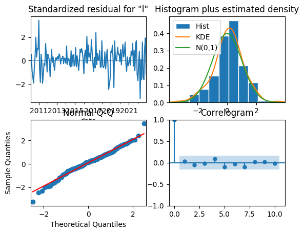

```python
print(acorr_ljungbox(result.resid, lags = 12).iloc[11,:])
result.plot_diagnostics()
plt.show()
```

### 7a. Forecasts

```python
forecast_nvda = test.copy()
forecast_nvda['sarima1'] = np.exp(result.get_prediction(start = test.index[0], end = test.index[-1]).predicted_mean)
```

#### Accuracy

```python
root_mean_squared_error(test.price, forecast_nvda.sarima1)
```

```
72.67073321126705
```

### 5b. Fit ARIMA with lowest BIC

```python
results_df.sort_values('bic').head()
```

|  | order | seasonal_order | aic | bic | converged |
| --- | --- | --- | --- | --- | --- |
| 3 | (0, 1, 0) | (0, 0, 0, 12) | -197.898695 | -194.855269 | True |
| 1 | (1, 1, 0) | (0, 0, 0, 12) | -198.106111 | -192.019260 | True |
| 2 | (0, 1, 1) | (0, 0, 0, 12) | -197.978774 | -191.891924 | True |
| 0 | (1, 1, 1) | (0, 0, 0, 12) | -198.436713 | -189.306437 | True |
| 8 | (2, 1, 0) | (0, 0, 0, 12) | -196.240636 | -187.110361 | True |

```python
sarima_model = SARIMAX(train.log_price, order=(0,1,0), seasonal_order = (0,0,0,12))
result = sarima_model.fit()
result.bic
```

```
np.float64(-194.8552694166753)
```

### 6b. Examine Residuals

```
lb_stat      8.091046
lb_pvalue    0.777976
Name: 12, dtype: float64
```

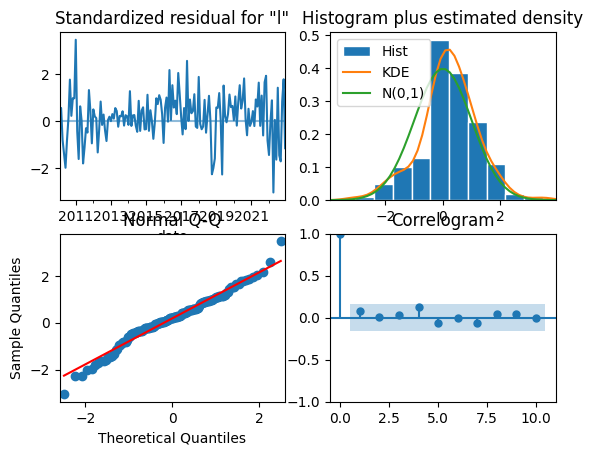

```python
print(acorr_ljungbox(result.resid, lags = 12).iloc[11,:])
result.plot_diagnostics()
plt.show()
```

### 7b. Forecast

```python
forecast_nvda['sarima2'] = np.exp(result.get_prediction(start = test.index[0], end = test.index[-1]).predicted_mean)
```

#### Accuracy

```python
root_mean_squared_error(test.price, forecast_nvda.sarima2)
```

```
71.60848808078896
```

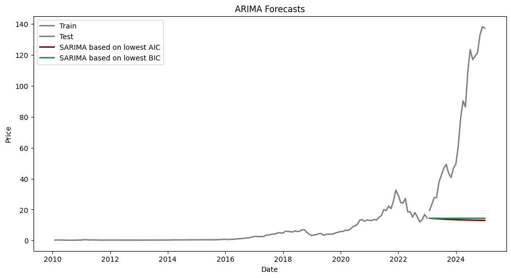

```python
plt.figure(figsize=(12,6))
plt.plot(train.index, train.price, label='Train', color = 'gray', lw = 2)
plt.plot(test.index, test.price, label='Test', color='gray', lw = 2)

plt.plot(test.index, forecast_nvda.sarima1, label='SARIMA based on lowest AIC', color = 'maroon', lw = 2)
plt.plot(test.index, forecast_nvda.sarima2, label='SARIMA based on lowest BIC', color = 'seagreen', lw = 2)

plt.title("ARIMA Forecasts")
plt.xlabel("Date")
plt.ylabel("Price")
plt.legend()
plt.show()
```

## Summary

In this note, we examined ARIMA models. We reviewed the steps in fitting an ARIMA model with two different kinds of time series.

This file was generated using Python 3.13.5 on Windows 10 with the following libraries: matplotlib 3.10.3, numpy 2.3.1, pandas 2.3.0, scikit-learn 1.7.1, scipy 1.16.0, statsmodels 0.14.5